# Mestrado em Hemoterapia: Bioestatística

## Inferência Estatística

## Inferência Estatística - Conceitos Básicos

Alguns conceitos básicos que foram vistos ontem:

**População**: todos os elementos ou resultados de um problema que está sendo estudado.

**Amostra:** qualquer subconjunto da população que contém os elementos que podem ser observados e é onde as quantidades de interesse podem ser medidas.

**Parâmetros**: Característica numérica (desconhecida) da distribuição dos elementos da população.

**Estimador/Estatística**: Função da amostra, construída com a finalidade de representar, ou estimar um parâmetro de interesse na população.

**Estimativa**: Valor numérico que um estimador assume para uma dada amostra.

## Inferência Estatística

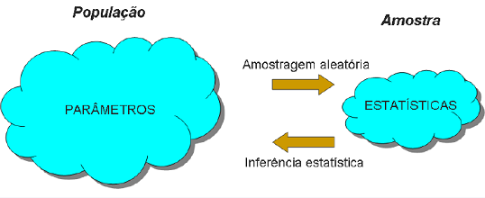

**Intervalo de Confiança**: Fornece um conjunto de valores plausíveis para um parâmetro populacional ou uma função de parâmetros populacionais.

**Teste de Hipóteses**: Regra de decisão que permite avaliar se os dados obtidos em uma amostra suportam uma hipótese de status quo a respeito do parâmetro de interesse.

## Inferência para duas populações

Hoje vamos focar em inferência para duas ou mais populações.

**Exemplos:**

1. Diferença no IMC para pessoas hipertensas e não-hipertensas.
2. Contagem de hemáceas para um grupo de pacientes e um grupo controle.
3. Pressão arterial de pessoas sedentárias versus pessoas fisicamente ativas.
4. Proporção de pacientes que melhoraram para dois tratamentos diferentes.

## Inferência para duas populações: intervalo de confiança para duas médias

## Intervalo de confiança para duas médias

De maneira geral, suponha que queremos estimar o parâmetro populacional \(\theta\) através de um intervalo.

Um intervalo de confiança (IC) para \(\theta\) é sempre da forma:

\[ \mbox{estimativa} \pm \mbox{margem de erro}\]

\[\hat{\theta} \pm \mbox{margem de erro}\]

Sendo:

- \(\hat \theta\) uma estimativa pontual de \(\theta\)
- **margem de erro:** quantidade que depende da distribuição amostral do estimador pontual de \(\theta\), do grau de confiança pré-estabelecido e do erro padrão da estimativa

## Intervalo de confiança para duas médias

**População 1:** Coletamos uma amostra aleatória \(X_1, X_2, \ldots,X_n\) de uma população com média \(\mu_1\) e a variância \(\sigma_1^2\) e usamos \(\bar{X}\) para estimar \(\mu_1\).

**População 2:** Coletamos uma amostra aleatória \(Y_1, Y_2, \ldots,Y_m\) de uma população com média \(\mu_2\) e a variância \(\sigma_2^2\) e usamos \(\bar{Y}\) para estimar \(\mu_2\).

A população 1 é independente da população 2.

**Condições:**

1. As populações 1 e 2 são aproximadamente normais ou
2. Os tamanhos amostrais \(n\) e \(m\) são suficientemente grandes.

Se pelo menos uma das condições acima é satisfeita, temos pelo TLC: \[\bar{X} \sim N\left(\mu_1,\frac{\sigma_1^2}{n} \right) \quad \mbox{e} \quad \bar{Y} \sim N\left(\mu_2,\frac{\sigma_2^2}{m} \right)\]

## Intervalo de confiança para duas médias

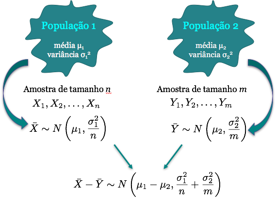

## Intervalo de confiança para duas médias

**Caso 1: Variâncias diferentes e conhecidas**

Assumindo que as duas amostras \(X_1, \ldots, X_n\) e \(Y_1, \ldots, Y_m\) são independentes com \(\sigma_1^2 \neq \sigma_2^2\) conhecidas, temos:

\[ \bar{X} - \bar{Y} \sim N\left(\mu_1 - \mu_2, \frac{\sigma_1^{2}}{n} + \frac{\sigma_2^{2}}{m} \right)\]

Um IC de \(100(1-\alpha)\%\) para \(\mu_1 - \mu_2\) é dado por: \[IC(\mu_1 - \mu_2, 1-\alpha) = (\bar{X} - \bar{Y}) \pm z_{\alpha/2} \sqrt{\frac{\sigma_1^{2}}{n} + \frac{\sigma_2^{2}}{m}}\]

## Relembrando: Como encontrar \(z_{\alpha/2}\)

\[P(|Z|\leq z_{\alpha/2})=P(-z_{\alpha/2}\leq Z \leq z_{\alpha/2})=1-\alpha\]

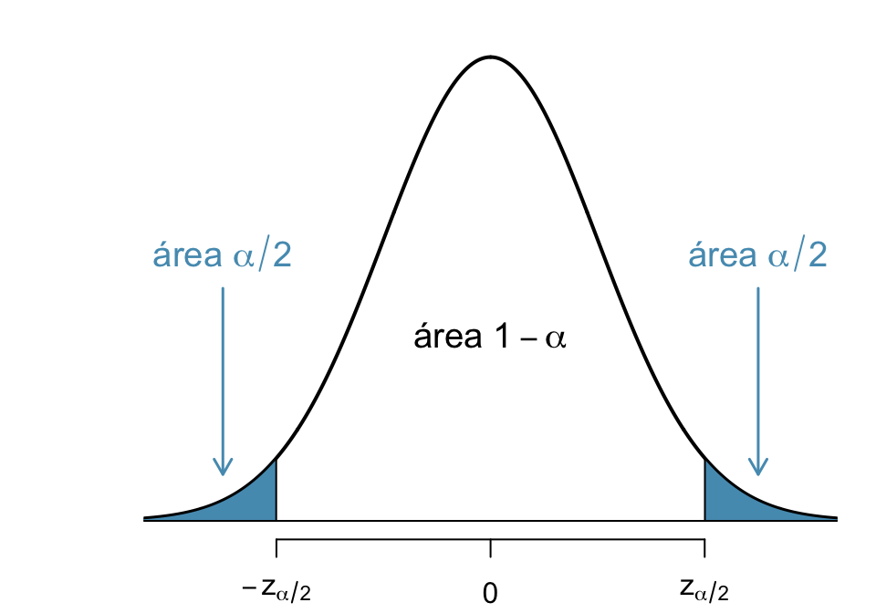

Procure na tabela o valor de \(z\) tal que a probabilidade acumulada até o valor de \(z\), isto é \(P(Z\leq z)=\Phi(z)\), seja \(1-\alpha/2\).

## Intervalo de confiança para duas médias

**Caso 2: Variâncias iguais e conhecidas**

Considere o caso em que as variâncias são conhecidas e idênticas, isto é, \(\sigma_1^2 = \sigma_2^2 = \sigma^2\).

Então, \[ \bar{X} - \bar{Y} \sim N\left(\mu_1 - \mu_2, \sigma^2 \left(\frac{1}{n} + \frac{1}{m}\right) \right)\]

Um IC de \(100(1-\alpha)\%\) para \(\mu_1 - \mu_2\) é dado por: \[IC(\mu_1 - \mu_2, 1-\alpha) = (\bar{X} - \bar{Y}) \pm z_{\alpha/2} \sqrt{\sigma^2 \left(\frac{1}{n} + \frac{1}{m} \right)}\]

## Intervalo de Confiança para duas médias

**Caso 3: Variâncias iguais e desconhecidas**

E se as variâncias das duas populações são idênticas porém desconhecidas, isto é, \(\sigma_1^2 = \sigma_2^2 = \sigma^2\), \(\sigma^2\) desconhecida?

Assim como no caso de uma média com variância desconhecida, usamos uma estimativa de \(\sigma^2\) e a distribuição normal é substituída pela distribuição \(t\).

No caso de duas populações, o estimador da variância \(\sigma^2\) é a combinação das variâncias amostrais de cada população, ou seja, \[S_p^2 = \frac{(n-1)S_1^2 + (m-1)S_2^2}{n+m-2},\] sendo \(S_i^2\) é a variância amostral da população \(i\).

## Intervalo de confiança para duas médias

Então temos:\(\displaystyle \quad T= \frac{(\bar{X} - \bar{Y}) - (\mu_1 - \mu_2)}{\displaystyle \sqrt{S_p^2 \left(\frac{1}{n} + \frac{1}{m}\right) }} \sim t_{n+m-2}\)

E um IC de \(100(1-\alpha)\%\) para \(\mu_1 - \mu_2\) é dado por: \[IC(\mu_1 - \mu_2, 1-\alpha) = (\bar{X} - \bar{Y}) \pm t_{n+m-2, \alpha/2} \sqrt{S_p^2 \left(\frac{1}{n} + \frac{1}{m} \right)}\]

**Observação:** Se \(n\) e \(m\) são pequenos, as duas amostras devem vir de populações aproximadamente normais. Se \(n\) e \(m\) são grandes, então a distribuição \(t\) com \(n+m-2\) graus de liberdade aproxima-se de uma normal.

## Relembrando: Como encontrar \(t_{\nu,\alpha/2}\)

\[P(-t_{\nu,\alpha/2} < T < t_{\nu,\alpha/2}) = 1-\alpha\]

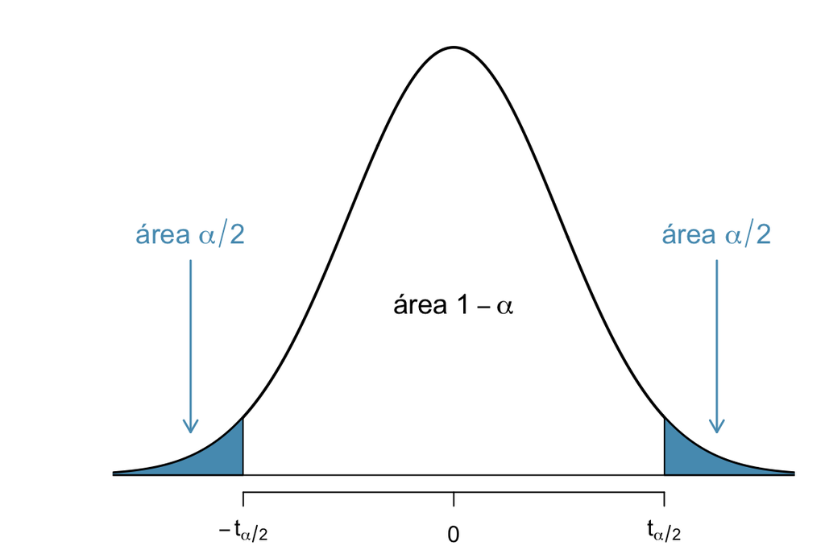

Nesse caso, \(\nu=n+m-2\) e os valores da distribuição \(t\) encontram-se tabelados.

## Intervalo de Confiança para duas médias

**Caso 4: Variâncias diferentes e desconhecidas**

Como aqui as variâncias são diferentes e desconhecidas, \(\sigma_1^2 \neq \sigma_2^2\), usamos como estimativas as variâncias amostrais de cada população.

E um IC de \(100(1-\alpha)\%\) para \(\mu_1 - \mu_2\) é dado por: \[IC(\mu_1 - \mu_2, 1-\alpha) = (\bar{X} - \bar{Y}) \pm t_{\nu, \alpha/2} \sqrt{ \frac{S_1^2}{n} + \frac{S_2^2}{m}},\] onde \(\nu\) são os graus de liberdade da distribuição \(t\) obtido por uma aproximação.

## Intervalo de confiança para duas médias

**Resumindo**

| Variâncias | \(IC(\mu_1 - \mu_2, 1-\alpha)\) |
| --- | --- |
| Diferentes e conhecidas (\(\sigma_1^2 \neq \sigma_2^2\)) | \((\bar{X} - \bar{Y}) \pm z_{\alpha/2} \sqrt{\displaystyle \frac{\sigma_1^{2}}{n} + \frac{\sigma_2^{2}}{m}}\) |
| Iguais e conhecidas (\(\sigma_1^2 = \sigma_2^2 =\sigma^2\)) | \((\bar{X} - \bar{Y}) \pm z_{\alpha/2} \sqrt{\displaystyle \sigma^2 \left(\frac{1}{n} + \frac{1}{m} \right)}\) |
| Iguais e desconhecidas (\(\sigma_1^2 = \sigma_2^2 =\sigma^2\)) | \((\bar{X} - \bar{Y}) \pm t_{n+m-2, \alpha/2} \sqrt{\displaystyle S_p^2 \left(\frac{1}{n} + \frac{1}{m} \right)}\) |
| Diferente e desconhecidas (\(\sigma_1^2 \neq \sigma_2^2\)) | \((\bar{X} - \bar{Y}) \pm t_{\nu, \alpha/2} \sqrt{\displaystyle \frac{S_1^2}{n} + \frac{S_2^2}{m}}\) |

## Exemplo: tempo de incubação de dois vírus

O tempo de incubação do vírus 1 segue uma distribuição normal com média \(\mu_1\) e desvio padrão \(\sigma_{1}=1.5\). Por outro lado, o tempo de incubação do vírus 2 segue uma distribuição normal com média \(\mu_2\) e desvio padrão \(\sigma_{2}=1\). Os tempos de incubação de ambos os vírus são considerados independentes.

Realizaram um estudo de controle e os tempos de incubação registrados foram (tempo em meses):

- X: tempo de incubação do vírus 1 (20 observações)

```
##  [1] 4.56 3.72 3.45 2.86 4.03 4.08 6.56 4.31 0.42 5.56 5.92 2.65 4.54 4.04
## [15] 4.23 6.24 6.16 5.46 3.22 2.28
```

- Y: tempo de incubação do vírus 2 (22 observações)

```
##  [1] 2.44 1.49 2.68 2.60 1.51 1.60 1.47 3.70 2.22 1.78 2.36 1.56 2.98 3.33
## [15] 2.22 0.58 2.26 2.26 1.92 0.50 1.17 1.70
```

## Exemplo: tempo de incubação de dois vírus

Suspeita-se que o tempo de incubação do vírus 1 é maior que o do vírus 2.

Construa um IC de \(95\%\) para a diferença do tempo médio de incubação entre os vírus, isto é, \(\mu_1 - \mu_2\).

Antes de tudo temos que calcular a média amostral das duas populações: \(\bar x=4.21\) e \(\bar y = 2.02\).

Pelo enunciado, as duas populações são normais e as variâncias são conhecidas: \(\sigma_1^2 = 2.25\) e \(\sigma_2^2= 1\).

Veja que as populações são normais, variâncias diferentes mas conhecidas. Além disso, \(n=20\) e \(m=22\).

## Exemplo: tempo de incubação

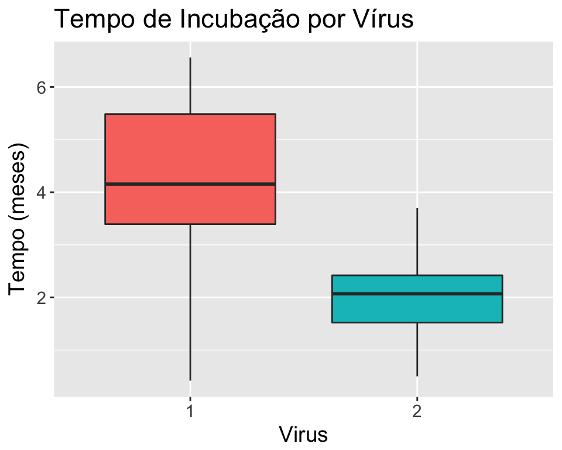

## Exemplo: tempo de incubação de dois vírus

Portanto, um Intervalo de \(95\%\) de confiança para \(\mu_1-\mu_2\) é dado por: \[\begin{aligned} IC(\mu_1-\mu_2, 0.95)&= (\bar{X} - \bar{Y}) \pm z_{0.025} \sqrt{\frac{\sigma_1^{2}}{n} + \frac{\sigma_2^{2}}{m}} \\ &= (4.21 - 2.02) \pm 1.96 \sqrt{\frac{2.25}{20} + \frac{1}{22}} \\ &= 2.19 \pm 0.78 = [1.41, 2.97] \end{aligned}\]

**Interpretação:** Com grau de confiança de 95%, estimamos que a diferença entre o tempo médio de incubação do vírus 1 para o vírus 2 está entre 1.41 e 2.97 meses.

Baseados nesse IC, o que podemos dizer a respeito da suspeita de que o tempo de incubação do vírus 1 é maior que o do vírus 2?

## Exemplo: tempo de incubação

Vamos assumir agora que as variâncias populacionais não fossem conhecidas, porém pode-se assumir que são iguais.

Primeiramente precisamos calcular as variâncias amostrais, ou seja, \[S_1^2=2.33 \qquad \mbox{e} \qquad S_2^2=0.63\]

Vamos então estimar a variância amostral combinada: \[\begin{aligned} S_p^2 &= \frac{(n-1)S_1^2 + (m-1)S_2^2}{n+m-2}\\ &= \frac{(20-1) (2.33) + (22-1)(0.63)}{20 + 22 - 2} \\ &= 1.44 \end{aligned}\]

## Exemplo: tempo de incubação

Nesse caso, um IC de 95% para \(\mu_1 - \mu_2\) é dado por: \[\begin{aligned} IC(\mu_1 - \mu_2, 0.95) &= (\bar{X} - \bar{Y}) \pm t_{n+m-2, 0.025} \sqrt{S_p^2 \left(\frac{1}{n} + \frac{1}{m} \right)} \\ &= (4.21 - 2.02) \pm 2.02 \sqrt{1.44 \left(\frac{1}{20} + \frac{1}{22}\right)} \\ &= 2.19 \pm 0.75 \\ &= [1.44, 2.94] \end{aligned} \]

## Intervalo de Confiança para duas proporções

Considere \(X_1, \ldots,X_{n_1}\) e \(Y_1, \ldots,Y_{n_2}\) duas amostras independentes de ensaios de Bernoulli tal que \(X \sim b(p_1)\) e \(Y \sim b(p_2)\), com probabilidade \(p_1\) e \(p_2\) de apresentarem uma certa característica.

Queremos encontrar um IC de confiança para a diferença entre as proporções \(p_1\) e \(p_2\), ou seja, um IC para \(p_1 – p_2\).

Em aulas anteriores vimos que: \[\hat p_1 \sim N\left(p_1,\frac{p_1(1-p_1)}{n_1} \right) \quad \mbox{e} \quad \hat p_2 \sim N\left(p_2,\frac{p_2(1-p_2)}{n_2} \right)\]

Como as variâncias de \(\hat p_1\) e \(\hat p_2\) dependem de \(p_1\) e \(p_2\) e, portanto, não são conhecidas, iremos usar uma estimativa dessas variâncias.

## Intervalo de Confiança para duas proporções

Ou seja, \[\hat p_1 \sim N\left(p_1,\frac{\hat p_1(1 - \hat p_1)}{n_1} \right) \quad \mbox{e} \quad \hat p_2 \sim N\left(p_2,\frac{\hat p_2(1 - \hat p_2)}{n_2} \right)\]

**Condições:** Todas as quantidades \(n_1\hat p_1, \; n_1(1- \hat p_1), \; n_2\hat p_2 \; \mbox{ e } \; n_2(1- \hat p_2)\) devem ser pelo menos igual a 10 para que a aproximação pela normal seja válida.

Então, \[Z = \frac{(\hat p_1 - \hat p_2) - (p_1 - p_2)}{\sqrt{\displaystyle \frac{\hat p_1(1 - \hat p_1)}{n_1} + \frac{\hat p_2(1 - \hat p_2)}{n_2}}} \sim N(0, 1)\]

## Intervalo de Confiança para duas proporções

Similar com o que fizemos para uma proporção, podemos então construir um IC de \(100(1-\alpha)\%\) para \(p_1 - p_2\) da seguinte forma:

\[P(-z_{\alpha/2} \leq Z \leq z_{\alpha/2}) = P \left( -z_{\alpha/2} \leq \frac{(\hat p_1 - \hat p_2) - (p_1 - p_2)}{\sqrt{\frac{\hat p_1(1 - \hat p_1)}{n_1} + \frac{\hat p_2 (1 - \hat p_2)}{n_2}}} \leq z_{\alpha/2}\right) = 1-\alpha\]

Então, um IC de \(100(1-\alpha)\%\) para \(p_1 - p_2\) é dado por: \[IC(p_1 - p_2, 1-\alpha) = (\hat p_1 - \hat p_2) \pm z_{\alpha/2} \sqrt{\frac{\hat p_1 (1 - \hat p_1)}{n_1} + \frac{\hat p_2 (1 - \hat p_2)}{n_2}}\]

## Exemplo: Ensaio Clínico

Um ensaio clínico é realizado para avaliar um novo tipo de tratamento contra uma doença e comparar os resultados com aqueles obtidos usando o tratamento tradicional.

Dos 50 pacientes tratados com o tratamento novo, 36 se curaram e dos 45 tratados com o antigo 29 se curaram.

Seja \(p_1\) a proporção de curados com o tratamento novo e \(p_2\) a proporção de curados com o tratamento antigo na população.

Encontre um IC de 99% para \(p_1 - p_2\).

## Exemplo: Ensaio Clínico

A proporção de curados pelos tratamentos novo e antigo na amostra são: \[\hat{p}_1 = \frac{36}{50}=0.72 \quad \mbox{e} \quad \hat p_2 = \frac{29}{45}=0.64 \]

Então um IC de 99% para \(p_1 - p_2\) é dado por: \[\begin{aligned} IC(p_1 - p_2, 0.99) &= (0.72 - 0.64) \pm z_{0.005} \sqrt{\frac{0.72 (0.28)}{50} + \frac{0.64 (0.36)}{45}} \\ &= 0.08 \pm 2.58 \times 0.096 \\ & = 0.08 \pm 0.247 = [-0.167, 0.327] \end{aligned} \]

Portanto, com grau de confiança de 99%, estimamos que a diferença entre as proporções de curados pelos tratamentos novo e antigo está entre -0.167 e 0.327.

## Leituras

- [Ross](http://www.sciencedirect.com/science/article/pii/B9780123743886000107): capítulo 10.
- [OpenIntro](https://www.openintro.org/stat/textbook.php): seção 5.3.1. e 6.2.2
- Magalhães: capítulo 9.

Slides produzidos pelos professores:

- Samara Kiihl
- Tatiana Benaglia
- Benilton Carvalho
- Rafael Maia